# POLS 5385 - Homework 4 - Regression Discontinuity

Don Lim

11/1/2021

```r
library(haven)
library(tidyverse)
library(rdrobust)
library(ggplot2)
library(estimatr)
library(formatR)
```

# Import Data

```r
LMB_Data <- read_dta("LMB-Data.dta")
```

# Creating d and x_c columns

```r
LMB_Data$d <- ifelse(LMB_Data$demvoteshare < 0.5, 0, 1)
LMB_Data$x_c <- LMB_Data$demvoteshare - 0.5
column_dem <- c("demvoteshare", "score", "age", "sex", "medianincome", "pcturban",
    "pctblack", "d", "x_c")
```

# Slide 19

```r
sum_dem1 <- LMB_Data %>%
    filter(LMB_Data$d == 1) %>%
    select(all_of(column_dem))

sum_dem0 <- LMB_Data %>%
    filter(LMB_Data$d == 0) %>%
    select(all_of(column_dem))

summary(sum_dem1)
```

```
##   demvoteshare        score             age             sex
##  Min.   :0.5002   Min.   :-27.92   Min.   :26.00   Min.   :1.000
##  1st Qu.:0.5916   1st Qu.: 37.11   1st Qu.:44.00   1st Qu.:1.000
##  Median :0.6870   Median : 66.00   Median :51.00   Median :1.000
##  Mean   :0.7279   Mean   : 58.39   Mean   :51.85   Mean   :1.036
##  3rd Qu.:0.8446   3rd Qu.: 80.46   3rd Qu.:59.00   3rd Qu.:1.000
##  Max.   :1.0000   Max.   :128.85   Max.   :88.00   Max.   :2.000
##                                    NA's   :40      NA's   :40
##   medianincome      pcturban         pctblack            d
##  Min.   : 1968   Min.   :0.1770   Min.   :0.0000   Min.   :1
##  1st Qu.: 6193   1st Qu.:0.5354   1st Qu.:0.0260   1st Qu.:1
##  Median : 9300   Median :0.8034   Median :0.0667   Median :1
##  Mean   :11199   Mean   :0.7460   Mean   :0.1342   Mean   :1
##  3rd Qu.:16048   3rd Qu.:0.9960   3rd Qu.:0.1929   3rd Qu.:1
##  Max.   :33404   Max.   :1.0000   Max.   :0.9205   Max.   :1
##  NA's   :2448    NA's   :2448     NA's   :2448
##       x_c
##  Min.   :0.0002307
##  1st Qu.:0.0915734
##  Median :0.1869732
##  Mean   :0.2278590
##  3rd Qu.:0.3445815
##  Max.   :0.5000000
##
```

```r
summary(sum_dem0)
```

```
##   demvoteshare        score             age             sex
##  Min.   :0.0000   Min.   :-27.92   Min.   :27.00   Min.   :1.000
##  1st Qu.:0.3204   1st Qu.:  4.49   1st Qu.:45.00   1st Qu.:1.000
##  Median :0.3836   Median : 12.28   Median :52.00   Median :1.000
##  Mean   :0.3663   Mean   : 17.58   Mean   :51.97   Mean   :1.035
##  3rd Qu.:0.4433   3rd Qu.: 25.16   3rd Qu.:59.00   3rd Qu.:1.000
##  Max.   :0.4999   Max.   :115.87   Max.   :86.00   Max.   :2.000
##                                    NA's   :109     NA's   :105
##   medianincome      pcturban         pctblack            d
##  Min.   : 2085   Min.   :0.1710   Min.   :0.0000   Min.   :0
##  1st Qu.: 6459   1st Qu.:0.5030   1st Qu.:0.0098   1st Qu.:0
##  Median : 9474   Median :0.6457   Median :0.0280   Median :0
##  Mean   :12003   Mean   :0.6661   Mean   :0.0553   Mean   :0
##  3rd Qu.:17738   3rd Qu.:0.8663   3rd Qu.:0.0600   3rd Qu.:0
##  Max.   :33404   Max.   :1.0000   Max.   :0.5420   Max.   :0
##  NA's   :1881    NA's   :1881     NA's   :1881
##       x_c
##  Min.   :-0.500000
##  1st Qu.:-0.179633
##  Median :-0.116419
##  Mean   :-0.133669
##  3rd Qu.:-0.056731
##  Max.   :-0.000125
##
```

# Slide 20

```r
dem1 <- LMB_Data %>%
    filter(LMB_Data$d == 1 & LMB_Data$demvoteshare > 0.4 & LMB_Data$demvoteshare <
        0.6) %>%
    select(all_of(column_dem))
summary(dem1)
```

```
##   demvoteshare        score             age             sex
##  Min.   :0.5002   Min.   :-18.40   Min.   :26.00   Min.   :1.000
##  1st Qu.:0.5228   1st Qu.: 52.27   1st Qu.:41.00   1st Qu.:1.000
##  Median :0.5465   Median : 70.03   Median :47.00   Median :1.000
##  Mean   :0.5485   Mean   : 64.40   Mean   :48.65   Mean   :1.032
##  3rd Qu.:0.5736   3rd Qu.: 80.18   3rd Qu.:55.00   3rd Qu.:1.000
##  Max.   :0.5998   Max.   :128.85   Max.   :87.00   Max.   :2.000
##                                    NA's   :16      NA's   :16
##   medianincome      pcturban         pctblack            d
##  Min.   : 2608   Min.   :0.1930   Min.   :0.0000   Min.   :1
##  1st Qu.: 6343   1st Qu.:0.5214   1st Qu.:0.0170   1st Qu.:1
##  Median : 8944   Median :0.6959   Median :0.0397   Median :1
##  Mean   :10691   Mean   :0.7110   Mean   :0.0751   Mean   :1
##  3rd Qu.:12894   3rd Qu.:0.9432   3rd Qu.:0.1046   3rd Qu.:1
##  Max.   :30726   Max.   :1.0000   Max.   :0.8893   Max.   :1
##  NA's   :744     NA's   :744      NA's   :744
##       x_c
##  Min.   :0.0002307
##  1st Qu.:0.0227644
##  Median :0.0464677
##  Mean   :0.0484703
##  3rd Qu.:0.0736306
##  Max.   :0.0997699
##
```

```r
dem0 <- LMB_Data %>%
    filter(LMB_Data$d == 0 & LMB_Data$demvoteshare > 0.4 & LMB_Data$demvoteshare <
        0.6) %>%
    select(all_of(column_dem))
summary(dem0)
```

```
##   demvoteshare        score             age             sex
##  Min.   :0.4000   Min.   :-27.92   Min.   :27.00   Min.   :1.000
##  1st Qu.:0.4264   1st Qu.:  4.22   1st Qu.:43.00   1st Qu.:1.000
##  Median :0.4498   Median : 11.86   Median :51.00   Median :1.000
##  Mean   :0.4503   Mean   : 16.76   Mean   :51.35   Mean   :1.026
##  3rd Qu.:0.4745   3rd Qu.: 24.35   3rd Qu.:59.00   3rd Qu.:1.000
##  Max.   :0.4999   Max.   :115.87   Max.   :83.00   Max.   :2.000
##                                    NA's   :74      NA's   :70
##   medianincome      pcturban         pctblack            d
##  Min.   : 2085   Min.   :0.1710   Min.   :0.0000   Min.   :0
##  1st Qu.: 5958   1st Qu.:0.4725   1st Qu.:0.0090   1st Qu.:0
##  Median : 8466   Median :0.6196   Median :0.0317   Median :0
##  Mean   :10335   Mean   :0.6470   Mean   :0.0634   Mean   :0
##  3rd Qu.:12684   3rd Qu.:0.8259   3rd Qu.:0.0849   3rd Qu.:0
##  Max.   :29850   Max.   :1.0000   Max.   :0.5420   Max.   :0
##  NA's   :1125    NA's   :1125     NA's   :1125
##       x_c
##  Min.   :-0.099996
##  1st Qu.:-0.073634
##  Median :-0.050198
##  Mean   :-0.049742
##  3rd Qu.:-0.025502
##  Max.   :-0.000125
##
```

# Slide 21

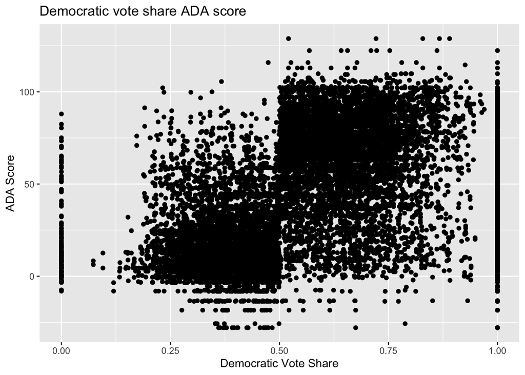

```r
ggplot(data = LMB_Data, aes(x = demvoteshare, y = score)) + geom_point() + labs(title = "Democratic vote share ADA score",
    x = "Democratic Vote Share", y = "ADA Score")
```

# Slide 22

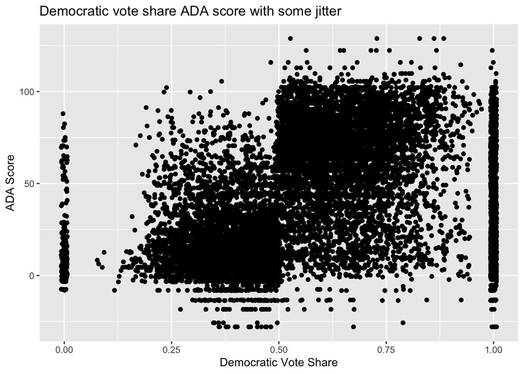

```r
ggplot(data = LMB_Data, aes(x = demvoteshare, y = score)) + geom_jitter(width = 0.007,
    height = 0.007) + labs(title = "Democratic vote share ADA score with some jitter",
    x = "Democratic Vote Share", y = "ADA Score")
```

# Discussion 1

On slide 20, we wanted to see if there were any significant differences particularly the standard deviations, between the covariates on either side of the cutoff (0.4<*demvoteshare*<0.5 and 0.5<*demvoteshare*<0.6). This is to check covariate balance. After plotting and including some jitter in the scatterplot (since the data points were too close on one another), we can observe a jump, or discontinuity, in the Americans for Democratic Action (ADA) score between winning and losing an election.

# Slide 31

```r
subset_lmb <- LMB_Data %>%
    select(all_of(column_dem)) %>%
    filter(LMB_Data$demvoteshare > 0.4 & LMB_Data$demvoteshare < 0.6)

lmb_4 <- LMB_Data %>%
    select(all_of(column_dem)) %>%
    filter(LMB_Data$demvoteshare > 0.4 & LMB_Data$demvoteshare < 0.5)

lmb_6 <- LMB_Data %>%
    select(all_of(column_dem)) %>%
    filter(LMB_Data$demvoteshare > 0.5 & LMB_Data$demvoteshare < 0.6)

lm1 <- lm_robust(score ~ d + x_c + I(x_c * x_c) + I(d * x_c) + I(d * x_c * x_c),
    data = subset_lmb)
summary(lm1)
```

```
##
## Call:
## lm_robust(formula = score ~ d + x_c + I(x_c * x_c) + I(d * x_c) +
##     I(d * x_c * x_c), data = subset_lmb)
##
## Standard error type:  HC2
##
## Coefficients:
##                  Estimate Std. Error t value   Pr(>|t|) CI Lower CI Upper   DF
## (Intercept)        17.712      1.184 14.9559  2.004e-49    15.39    20.03 4626
## d                  45.928      1.852 24.7987 1.425e-127    42.30    49.56 4626
## x_c                38.640     54.129  0.7138  4.754e-01   -67.48   144.76 4626
## I(x_c * x_c)      295.172    514.038  0.5742  5.658e-01  -712.59  1302.93 4626
## I(d * x_c)          6.507     88.661  0.0734  9.415e-01  -167.31   180.33 4626
## I(d * x_c * x_c) -744.025    867.517 -0.8576  3.911e-01 -2444.77   956.72 4626
##
## Multiple R-squared:  0.5549 ,    Adjusted R-squared:  0.5544
## F-statistic:  1132 on 5 and 4626 DF,  p-value: < 2.2e-16
```

# Slide 32

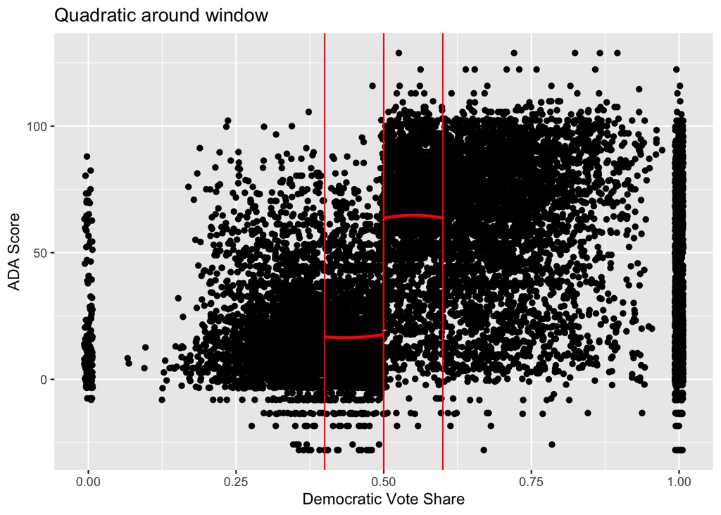

```r
ggplot(data = LMB_Data, aes(x = demvoteshare, y = score)) + geom_jitter(width = 0.007,
    height = 0.007) + labs(title = "Quadratic around window", x = "Democratic Vote Share",
    y = "ADA Score") + geom_vline(xintercept = 0.4, color = "red") + geom_vline(xintercept = 0.5,
    color = "red") + geom_vline(xintercept = 0.6, color = "red") + stat_smooth(data = lmb_4,
    method = "lm", formula = y ~ poly(x, 2), se = F, color = "red") + stat_smooth(data = lmb_6,
    method = "lm", formula = y ~ poly(x, 2), se = F, color = "red")
```

# Slide 33

```r
lm2 <- lm_robust(score ~ d + x_c + I(d * x_c), data = subset_lmb)
summary(lm2)
```

```
##
## Call:
## lm_robust(formula = score ~ d + x_c + I(d * x_c), data = subset_lmb)
##
## Standard error type:  HC2
##
## Coefficients:
##             Estimate Std. Error t value   Pr(>|t|) CI Lower CI Upper   DF
## (Intercept)   17.227     0.7557 22.7955 4.230e-109    15.75    18.71 4628
## d             47.159     1.2178 38.7257 1.957e-284    44.77    49.55 4628
## x_c            9.422    13.0537  0.7218  4.705e-01   -16.17    35.01 4628
## I(d * x_c)    -9.128    21.9320 -0.4162  6.773e-01   -52.12    33.87 4628
##
## Multiple R-squared:  0.5548 ,    Adjusted R-squared:  0.5545
## F-statistic:  1887 on 3 and 4628 DF,  p-value: < 2.2e-16
```

# Slide 34

```r
lm3 <- lm_robust(score ~ d, data = subset_lmb)
summary(lm3)
```

```
##
## Call:
## lm_robust(formula = score ~ d, data = subset_lmb)
##
## Standard error type:  HC2
##
## Coefficients:
##             Estimate Std. Error t value Pr(>|t|) CI Lower CI Upper   DF
## (Intercept)    16.76     0.3766   44.50        0    16.02    17.50 4630
## d              47.64     0.6349   75.03        0    46.40    48.89 4630
##
## Multiple R-squared:  0.5548 ,    Adjusted R-squared:  0.5547
## F-statistic:  5630 on 1 and 4630 DF,  p-value: < 2.2e-16
```

# Slide 35

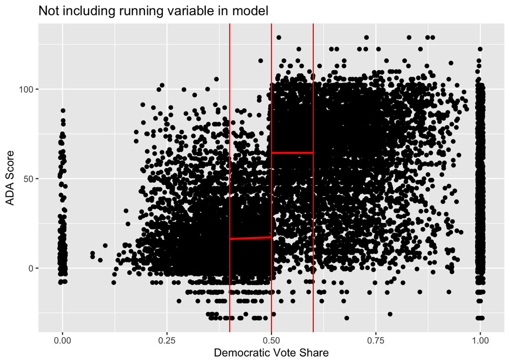

```r
lmb_41 <- LMB_Data %>%
    select(all_of(column_dem)) %>%
    filter(LMB_Data$demvoteshare > 0.4 & LMB_Data$demvoteshare < 0.5 & LMB_Data$democrat ==
        0)

lmb_61 <- LMB_Data %>%
    select(all_of(column_dem)) %>%
    filter(LMB_Data$demvoteshare > 0.5 & LMB_Data$demvoteshare < 0.6 & LMB_Data$democrat ==
        1)

ggplot(data = LMB_Data, aes(x = demvoteshare, y = score)) + geom_jitter(width = 0.007,
    height = 0.007) + labs(title = "Not including running variable in model", x = "Democratic Vote Share",
    y = "ADA Score") + geom_vline(xintercept = 0.4, color = "red") + geom_vline(xintercept = 0.5,
    color = "red") + geom_vline(xintercept = 0.6, color = "red") + stat_smooth(data = lmb_41,
    method = "lm", formula = y ~ x, se = F, color = "red") + stat_smooth(data = lmb_61,
    method = "lm", formula = y ~ x, se = F, color = "red")
```

# Discussion 2

As I noted in discussion 1, we notice a discontinuity in ADA score between winners and losers of an election. If the regression discontinuity method is valid, then the average voting records of Democrats who are *barely* elected should credibly represent, on average, how Democrats *would have* voted in districts that were actually, barely won by Republicans (and the same would occur for Republicans in barely won Democrat districts). In other words, as we compare elections that are closer and closer, all predetermined characteristics of Republican and Democratic districts become more and more similar. This is to test the convergence and divergence theories.

In the previous slides, we test the bandwidth *h*=0.1 around *c*=0.5. That is, we set a baseline at the cutoff of winning in a first past the post election at 0.5, or 50%, of the vote share. Winners with the bandwidth of 0.1 less and greater than the cutoff are considered close enough to be considered random. This bandwidth, as we examine later, may not be the best in terms of trade-off between variance and bias, but for now, it should suffice as a preliminary examination of the data.

On slide 31, we want to see how well a quadratic fits into our parametric model around our restricted window. Next we examine a linear fit around our restricted window. And finally, we examine our parametric model without a running variable around our restricted window.

All this was to show that any parametric model makes an assumption on the functional form on the relationship between *X* and *Y*. The best model depends on whether we use all the observations or not. Choosing the optimal window is important since that would affect how our covariates are balanced.

# Slide 49

```r
LMB_Data$score <- LMB_Data$score
x_lmb <- LMB_Data$demvoteshare

rd1 <- rdrobust(LMB_Data$score, LMB_Data$demvoteshare, c = 0.5, h = 0.1, p = 2)
```

```
## [1] "Mass points detected in the running variable."
```

```r
summary(rd1)
```

```
## Call: rdrobust
##
## Number of Obs.                13577
## BW type                      Manual
## Kernel                   Triangular
## VCE method                       NN
##
## Number of Obs.                 5480         8097
## Eff. Number of Obs.            2428         2204
## Order est. (p)                    2            2
## Order bias  (q)                   3            3
## BW est. (h)                   0.100        0.100
## BW bias (b)                   0.100        0.100
## rho (h/b)                     1.000        1.000
## Unique Obs.                    2770         3351
##
## =============================================================================
##         Method     Coef. Std. Err.         z     P>|z|      [ 95% C.I. ]
## =============================================================================
##   Conventional    45.915     1.717    26.741     0.000    [42.550 , 49.280]
##         Robust         -         -    19.826     0.000    [40.902 , 49.877]
## =============================================================================
```

# Slide 50

```r
rd2 <- rdrobust(LMB_Data$score, LMB_Data$demvoteshare, c = 0.5, p = 2, bwselect = "mserd")
```

```
## [1] "Mass points detected in the running variable."
```

```r
summary(rd2)
```

```
## Call: rdrobust
##
## Number of Obs.                13577
## BW type                       mserd
## Kernel                   Triangular
## VCE method                       NN
##
## Number of Obs.                 5480         8097
## Eff. Number of Obs.            3197         2965
## Order est. (p)                    2            2
## Order bias  (q)                   3            3
## BW est. (h)                   0.136        0.136
## BW bias (b)                   0.185        0.185
## rho (h/b)                     0.732        0.732
## Unique Obs.                    2770         3351
##
## =============================================================================
##         Method     Coef. Std. Err.         z     P>|z|      [ 95% C.I. ]
## =============================================================================
##   Conventional    46.227     1.460    31.666     0.000    [43.366 , 49.088]
##         Robust         -         -    27.531     0.000    [42.768 , 49.324]
## =============================================================================
```

# Slide 51

```r
rd3 <- rdrobust(LMB_Data$score, LMB_Data$demvoteshare, c = 0.5, bwselect = "mserd")
```

```
## [1] "Mass points detected in the running variable."
```

```r
summary(rd3)
```

```
## Call: rdrobust
##
## Number of Obs.                13577
## BW type                       mserd
## Kernel                   Triangular
## VCE method                       NN
##
## Number of Obs.                 5480         8097
## Eff. Number of Obs.            2112         1893
## Order est. (p)                    1            1
## Order bias  (q)                   2            2
## BW est. (h)                   0.086        0.086
## BW bias (b)                   0.141        0.141
## rho (h/b)                     0.609        0.609
## Unique Obs.                    2770         3351
##
## =============================================================================
##         Method     Coef. Std. Err.         z     P>|z|      [ 95% C.I. ]
## =============================================================================
##   Conventional    46.491     1.241    37.477     0.000    [44.060 , 48.923]
##         Robust         -         -    31.425     0.000    [43.293 , 49.052]
## =============================================================================
```

# Slide 53

```
## [1] "Mass points detected in the running variable."
```

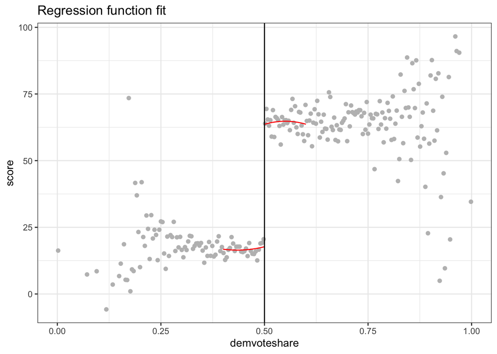

```r
rdplot(LMB_Data$score, LMB_Data$demvoteshare, c = 0.5, h = 0.1, p = 2, x.label = "demvoteshare",
    y.label = "score", title = "Regression function fit", col.dots = "gray")
```

# Slide 55

```
## [1] "Mass points detected in the running variable."
```

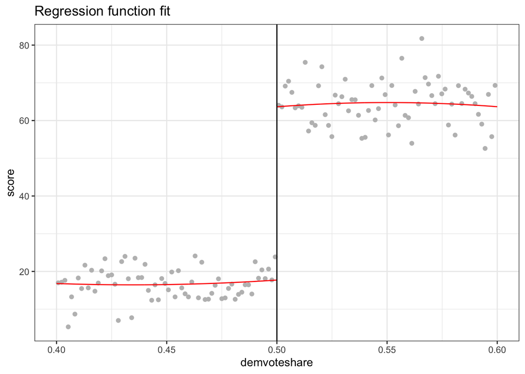

```r
rdplot(subset_lmb$score, subset_lmb$demvoteshare, c = 0.5, h = 0.1, p = 2, x.label = "demvoteshare",
    y.label = "score", title = "Regression function fit", col.dots = "gray")
```

# Slide 56

```r
rd4 <- rdrobust(LMB_Data$score, LMB_Data$demvoteshare, c = 0.5, covs = LMB_Data$pcturban +
    LMB_Data$pctblack, bwselect = "mserd")
```

```
## [1] "Mass points detected in the running variable."
```

```r
summary(rd4)
```

```
## Call: rdrobust
##
## Number of Obs.                 9248
## BW type                       mserd
## Kernel                   Triangular
## VCE method                       NN
##
## Number of Obs.                 3599         5649
## Eff. Number of Obs.            1319         1488
## Order est. (p)                    1            1
## Order bias  (q)                   2            2
## BW est. (h)                   0.102        0.102
## BW bias (b)                   0.157        0.157
## rho (h/b)                     0.653        0.653
## Unique Obs.                    1728         2394
##
## =============================================================================
##         Method     Coef. Std. Err.         z     P>|z|      [ 95% C.I. ]
## =============================================================================
##   Conventional    46.755     1.537    30.420     0.000    [43.743 , 49.767]
##         Robust         -         -    25.134     0.000    [43.184 , 50.488]
## =============================================================================
```

# Discussion 3

On slide 49, we run a local polynomial regression discontinuity with robust bias-corrected confidence intervals and inference procedures to obtain an estimate of the average treatment effect of winning the election, 45.915. We are forcing the same bandwidth (*h*=0.10) around the cutoff like the previous slides. On slide 50, we allow the ‘rdrobust’ package function to obtain the optimal bandwidth with the bias-variance trade-off in mind. The bandwidth estimate is 0.136, which is not far from the 0.1 we were using earlier. On slide 51, we use the default polynomial degree (*p*=1) for our model. This, as we notice, results in a change in the bandwidth from 0.136 to 0.086—a smaller bandwidth.

Next, we plot the results we obtained on slides 49-51. On slide 53, we plot the binned the sample and on slide 55, narrow the range to the cutoff around our bandwidth. On slide 56, we incorporate the covariates *pcturban* and *pctblack* to see if they would change our estimates of the treatment effect. I obtained slightly different results than the slides. My bandwidth is *h*=0.102 instead of 0.106 and my estimate and standard errors are slightly higher. However, the estimated treatment effect still matches up with the estimates obtained in previous slides and is within the 95% confidence interval. Including covariates did not change the estimate of treatment effects since they are balanced.

This means we obtained the same results as the original Lee, Moretti, and Butler (2004) paper. By focusing on narrowly won elections, we generated a quasi-experimental estimate. We can conclude that voters merely elect policies and that the strength of the electoral win has no effect on the winner’s behavior. The treatment effect at the cutoff 0.5 is around 45-47.